Lake Name: Smith Pond

Lake acreage: 43.9

County: STEUBEN

PWLID: 0502-0012

Waterbody Classification: B

Coordinates: 42.388802,-77.474403

Is this waterbody a public water supply: No

Are there DOH desingated beaches on this waterbody: No

Open Water Indicators

2018 Sampling Results

Seasonal Change

06-10

06-26

07-08

07-23

08-05

08-20

09-02

09-18

Clarity (m)

1.40

1.25

1.50

0.75

0.80

0.80

1.00

0.95

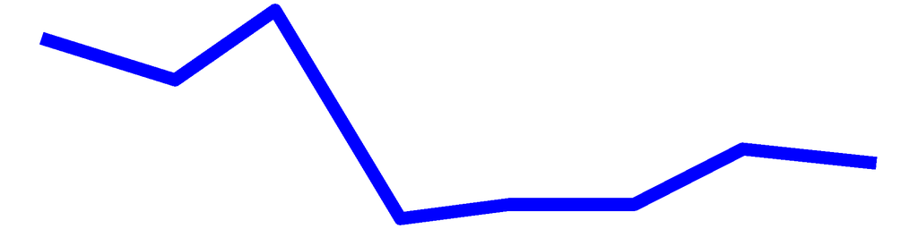

Surface TP (mg/L)

0.05

0.05

0.03

0.05

0.04

0.04

0.04

0.03

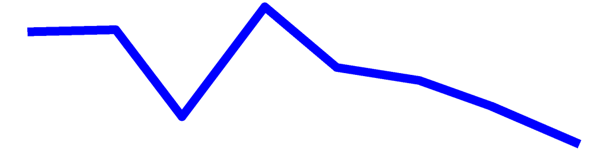

Surface TDP (mg/L)

0.02

0.02

0.03

0.01

0.01

0.02

0.01

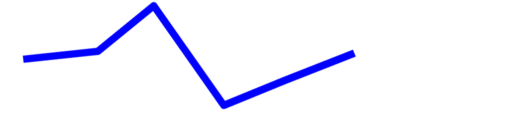

Deep TP (mg/L)

0.07

0.20

0.41

0.05

0.38

0.13

0.09

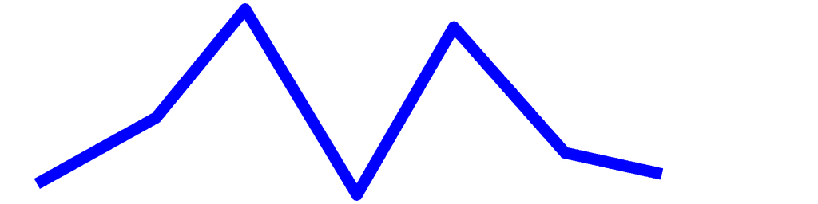

Deep TDP (mg/L)

0.04

0.13

0.41

0.01

0.17

0.09

0.04

0.04

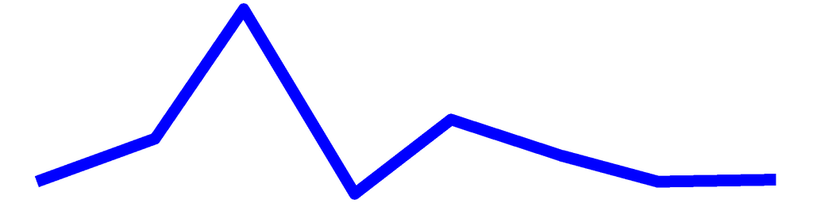

TN (mg/L)

0.84

1.10

0.88

1.12

1.45

1.18

1.27

1.18

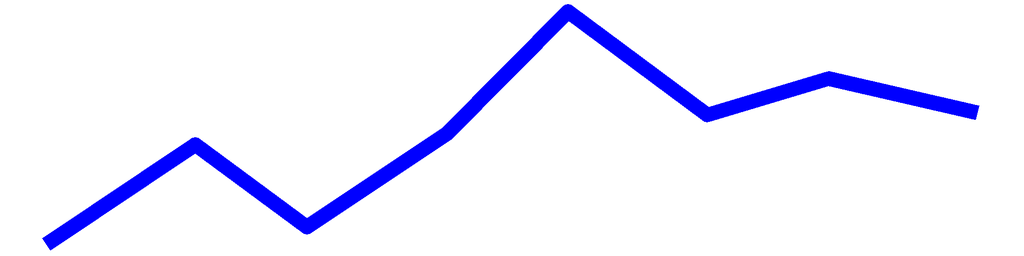

TDN (mg/L)

0.74

0.96

0.76

0.89

1.27

1.04

1.10

1.04

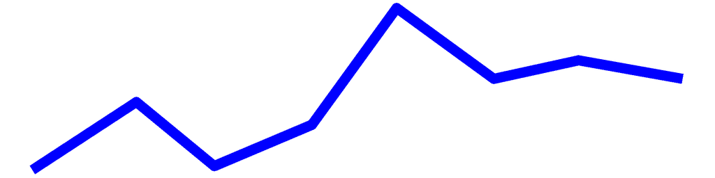

TN:TP

18.28

23.80

25.50

22.91

35.16

29.82

35.28

38.06

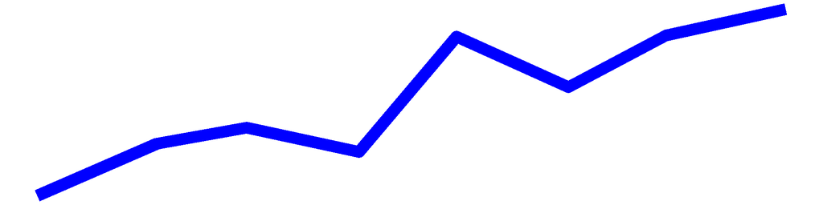

Surface NH3 (mg/L)

0.02

0.04

0.03

0.09

0.04

0.26

0.03

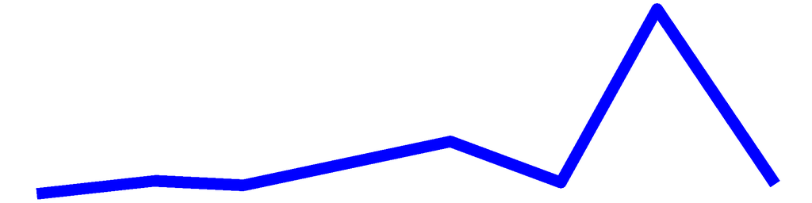

Deep NH3 (mg/L)

0.47

1.33

4.68

0.20

2.45

1.55

1.44

1.12

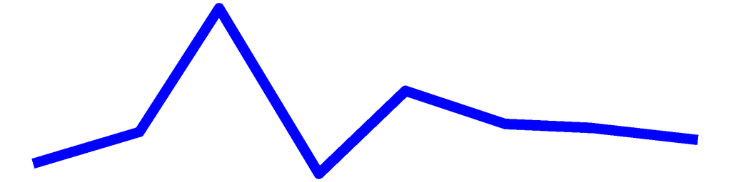

Chl.a (ug/L)

27.50

16.50

50.30

49.70

27.20

25.10

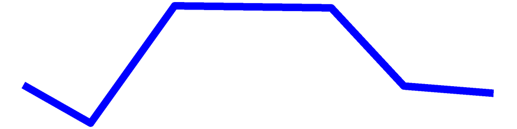

pH

7.47

8.48

7.95

8.57

9.18

8.33

8.41

7.64

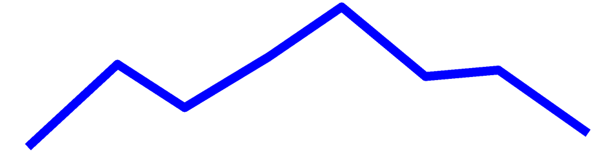

Cond (umho/cm)

213.20

222.60

239.40

197.80

137.30

225.40

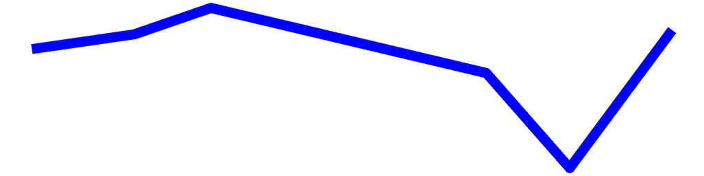

Surface Calcium (mg/L)

Bottom Calcium (mg/L)

Surface Chloride (mg/L)

22.90

16.50

Bottom Chloride (mg/L)

Upper Temp (degC)

24.00

21.00

25.00

23.00

26.00

24.00

24.00

25.00

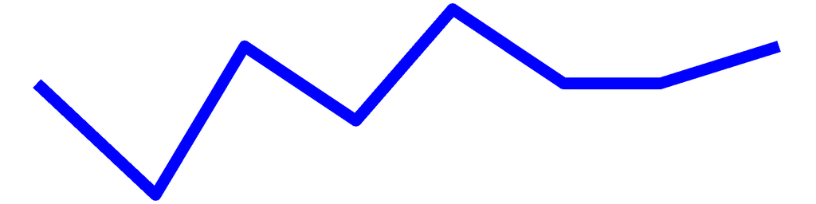

Deep Temp (degC)

16.00

10.00

9.00

18.00

12.00

15.00

14.00

18.00

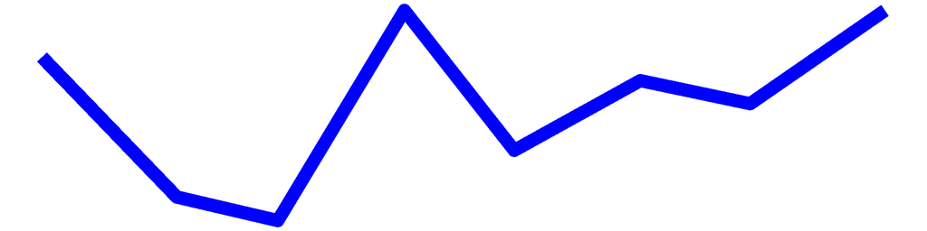

FP BG Chl.a (ug/L)

20.35

48.28

30.38

102.08

86.48

79.35

52.45

45.26

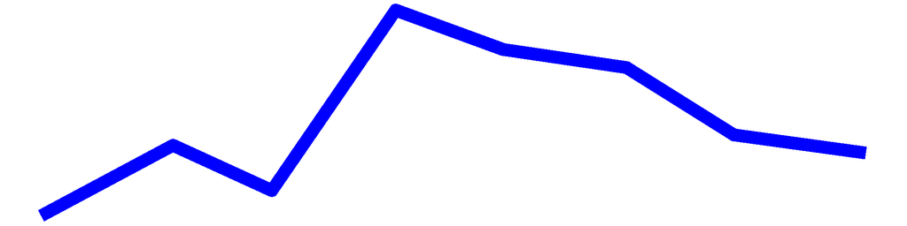

## Smith Pond – Sampling Season Results

### HABs Status

#### Open Water Algae

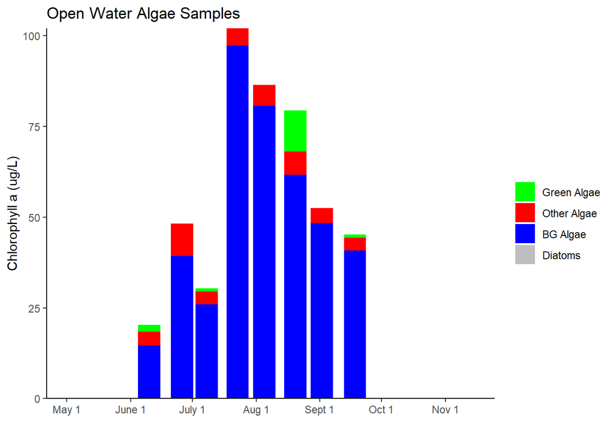

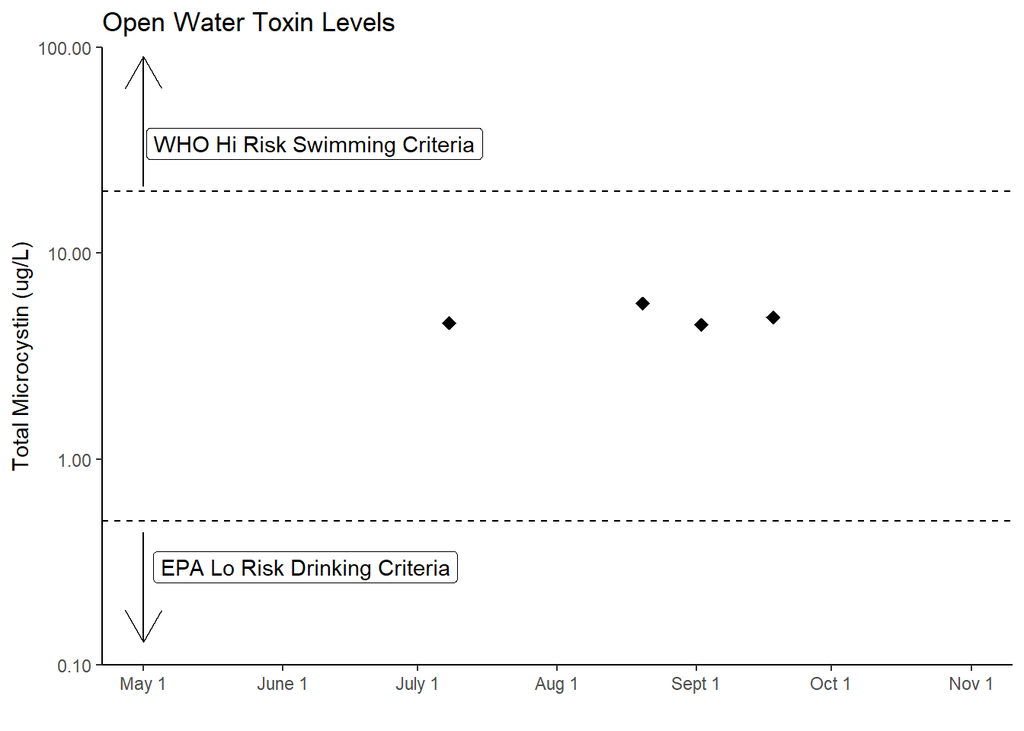

## Smith Pond Long-Term Trend Analysis

#### Clarity

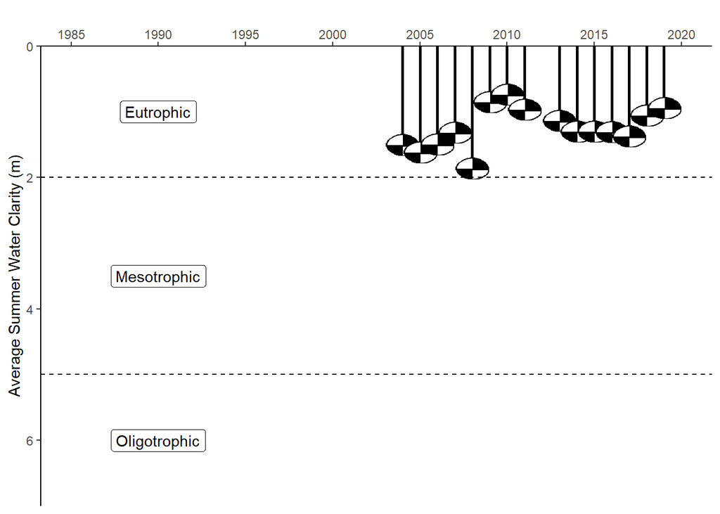

#### Chlorophyll *a*

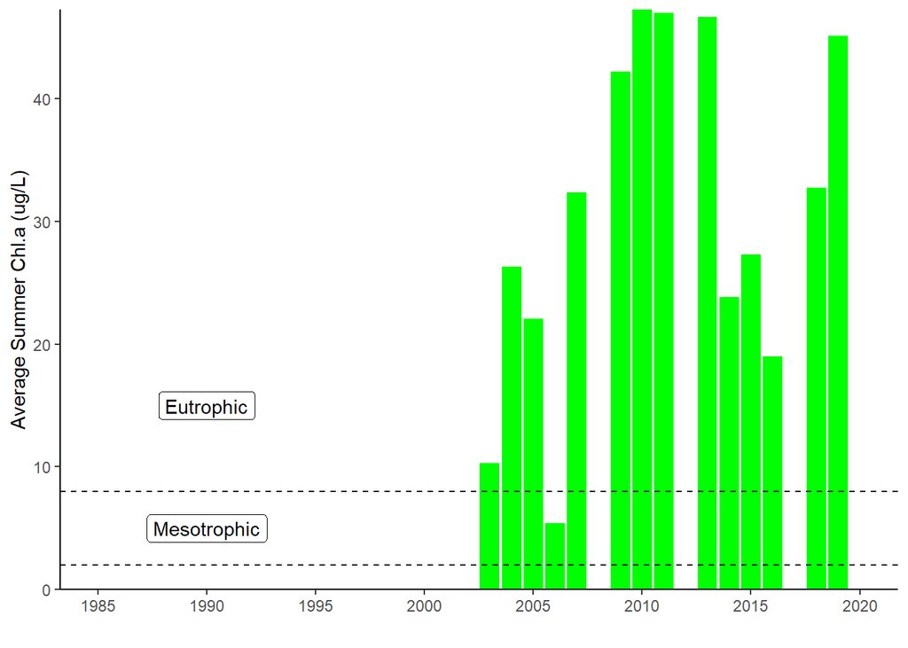

#### Surface and Deep Phosphorus

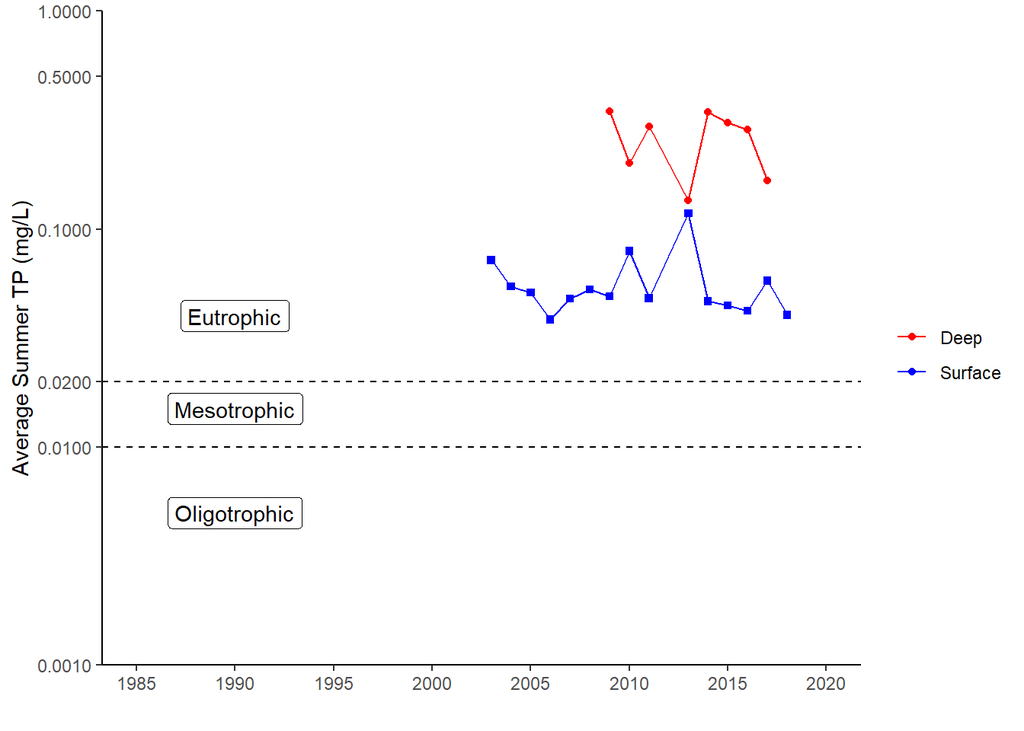

#### Nitrogen

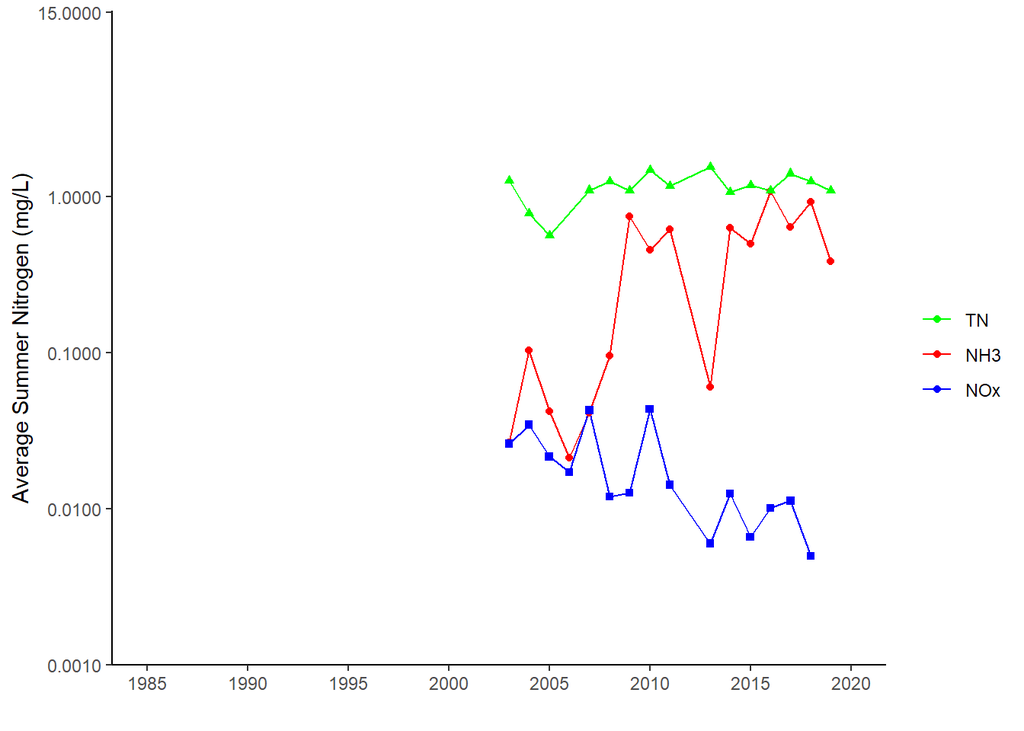

#### TN : TP

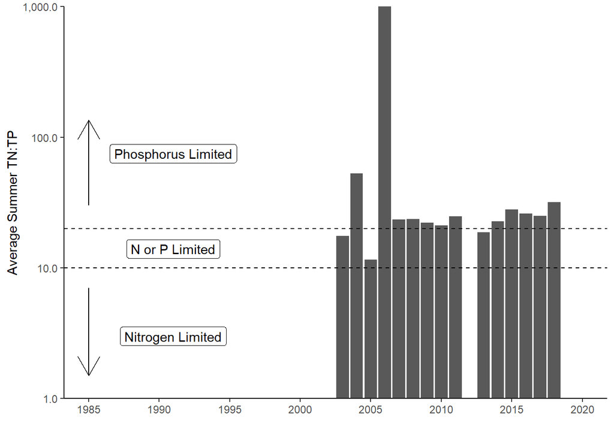

#### pH

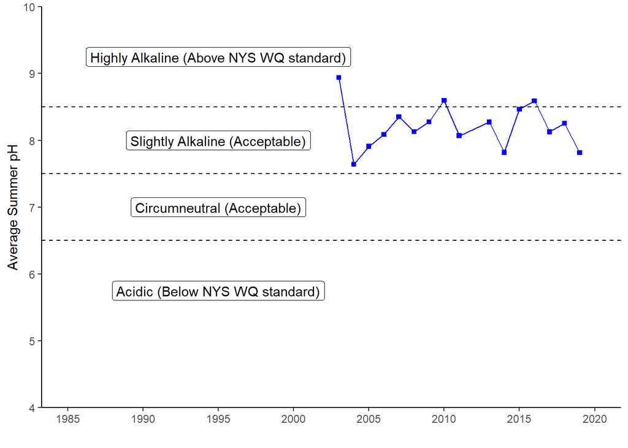

#### Specific Conductance

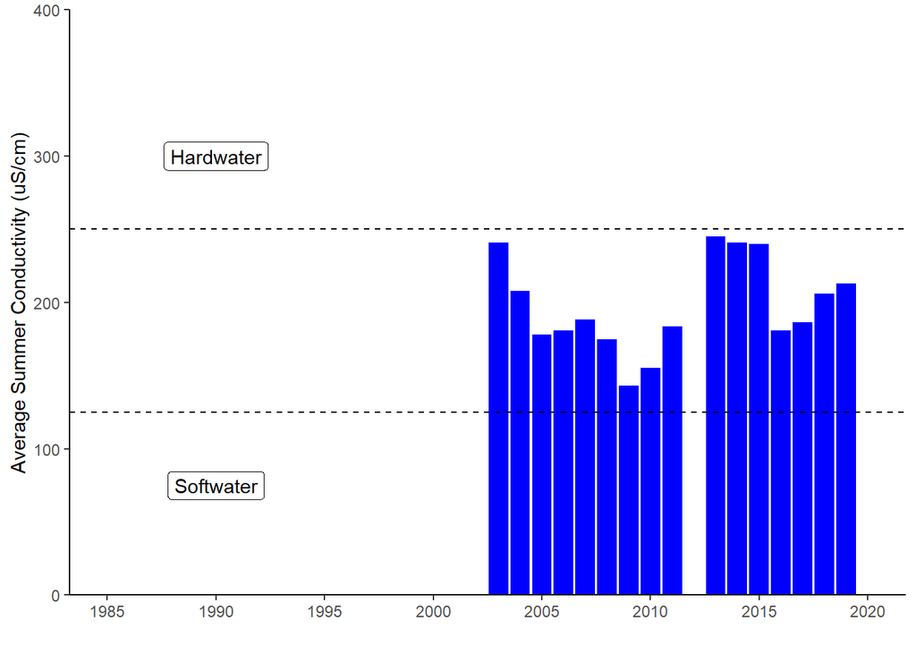

#### Calcium

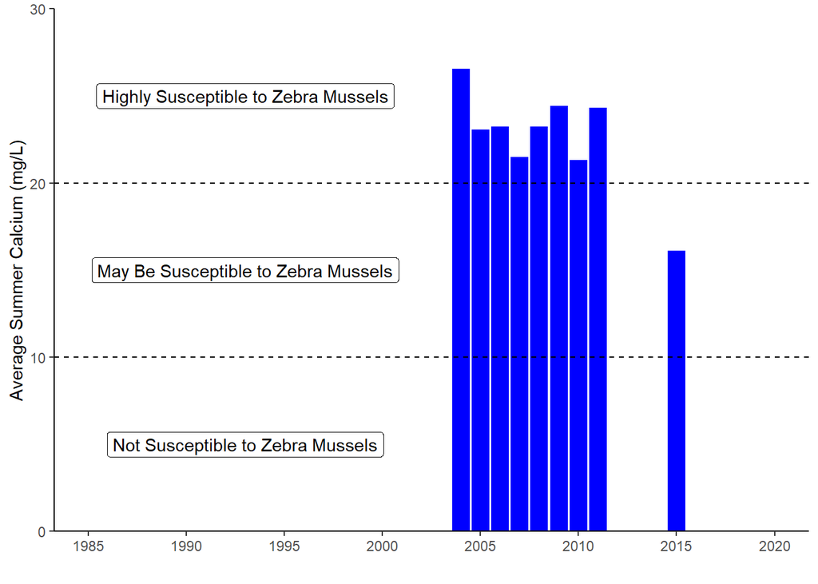

#### Chloride

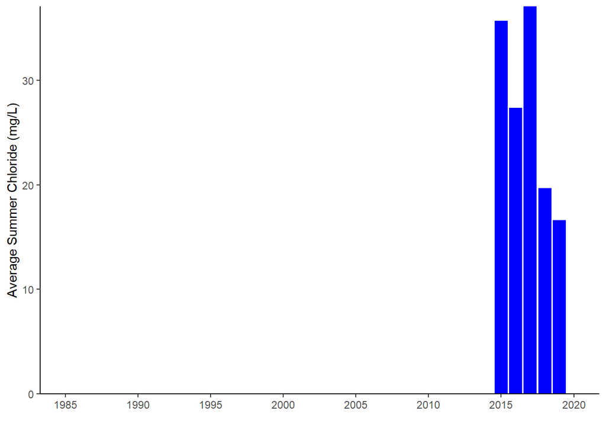

#### Color

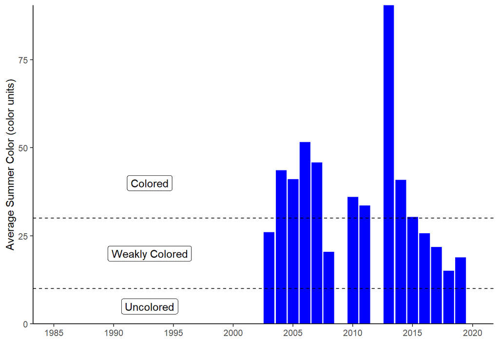

#### Surface and Deep Temperature

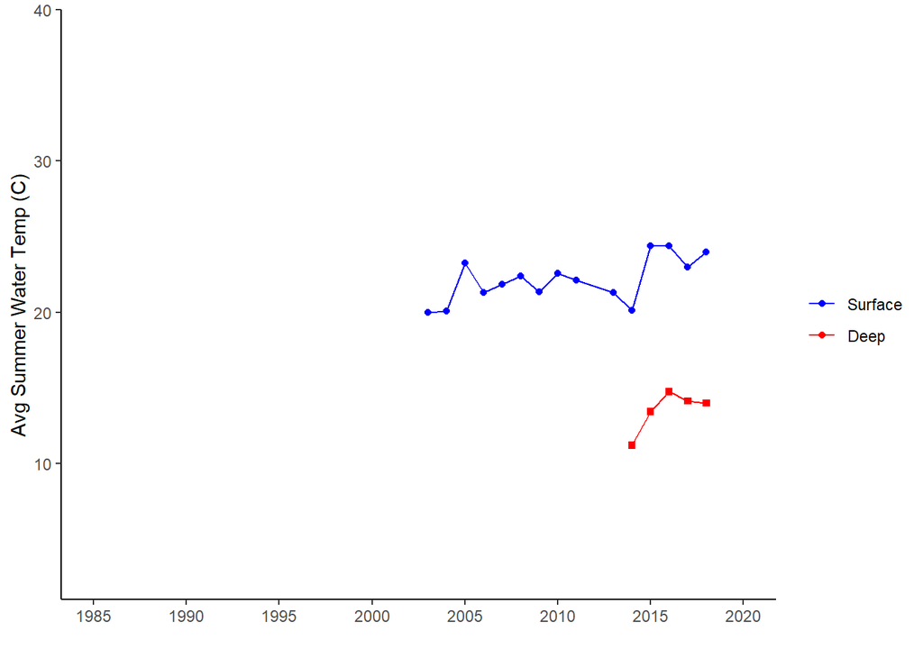

#### Lake Perception

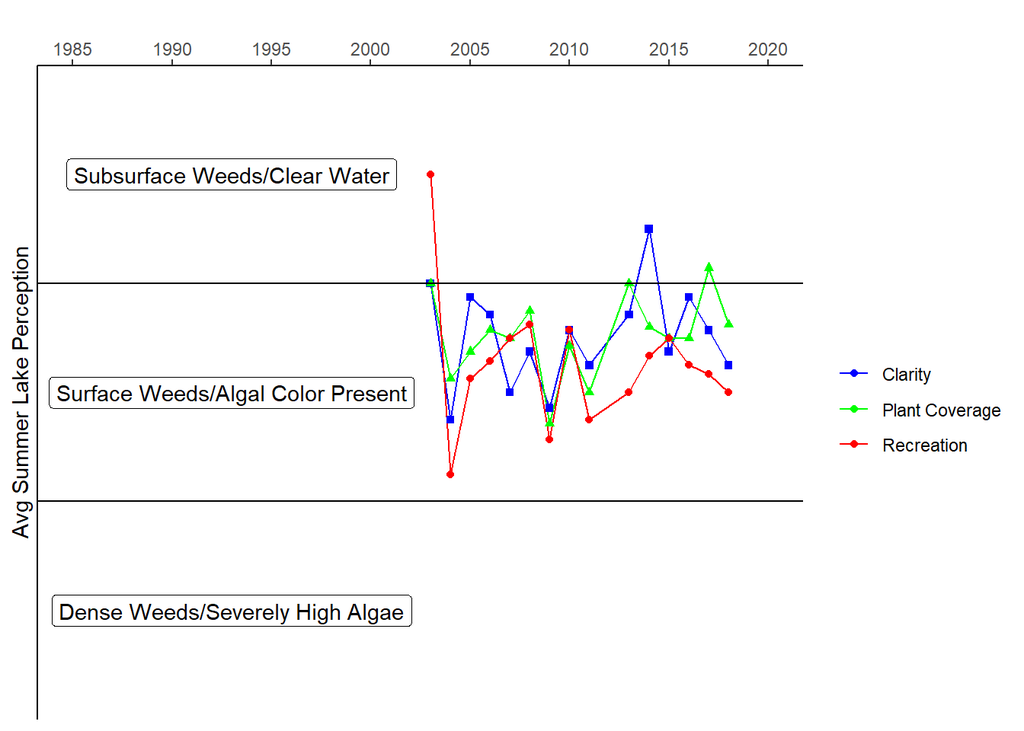

## Smith Pond - In-Season Analysis

#### In Season Water Clarity

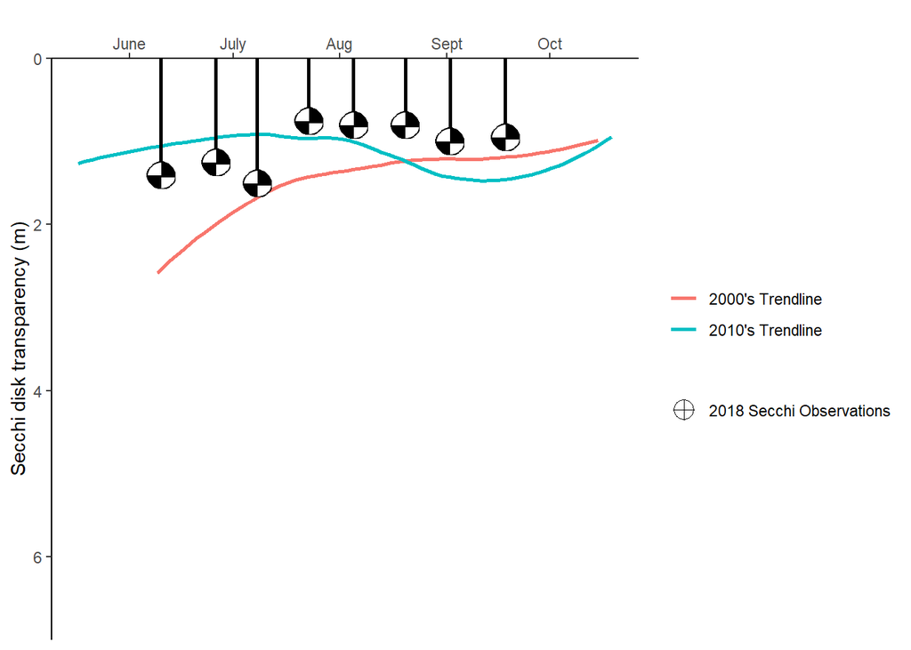

#### In Season Water Temperature

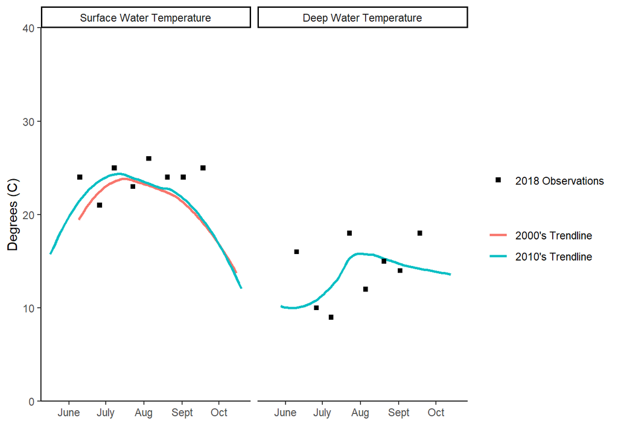